# R Notebook

## Introduction

One of the reviewers was interested in seeing if fine-mapping (with Susie) performed better than our clumping and thresholding in terms of bias and prediction accuracy in the polygenic score. We test this idea here.

Briefly, I ran susie’s algorithm with for every 100kb window individually to identify the variant with the highest posterior inclusion probability. We set a value for L=1 because we know that there’s only one causal variant in each window. We used the original effect size (as opposed to that re-estimated by susie) to construct the polygenic scores.

## Implementation

Let’s load necessary libraries.

```r
library(ggplot2)
library(data.table)
library(dplyr)
library(rprojroot)
library(patchwork)
F = is_rstudio_project$make_fix_file()
```

Read the polygenic scores constructed using effect sizes of variants called by susie using summary statistics from GWAS with no correction and using rare-PCA to correct for population structure. Also, load the (true) genetic values for each individual and their longitude and latitude information.

```r
#no correction
prs.pcs0 = fread(F("gwas/grid/genotypes/tau100/ss500/test/susie_prs/prs_susie_smooth.all.pcs0.sscore"))
#rare-PCA
prs.re = fread(F("gwas/grid/genotypes/tau100/ss500/test/susie_prs/prs_susie_smooth.all.re.sscore"))
colnames(prs.pcs0) = colnames(prs.re)=c("rep","IID","lead","marginal")
#remove betas marginal over the windows
#we estimated these but they don't really work because it requires knowledge of the phase of the variants etc. which we have but complicated to do.
#I've observed in many cases that the effects are very similar
prs.pcs0 = prs.pcs0 %>% select(rep,IID,lead)
prs.re = prs.re %>% select(rep,IID,lead)
#load genetic values
gvalues = fread(F("gwas/grid/genotypes/tau100/ss500/test/gvalue/genos_grid_d36_m0.05_s500_t100.rmdup.test.all.gvalue.sscore.gz"))
colnames(gvalues) = c("rep","IID","dosage","gvalue")
#load pop file (lat and long information)
pop = fread(F("gwas/grid/genotypes/tau100/ss500/iid_test.txt"))
prs.pcs0$correction="pcs0"
prs.re$correction="re"
prs.susie= rbind(prs.pcs0,prs.re)
prs.susie = merge(prs.susie, pop)
prs.susie = merge(prs.susie, gvalues, by = c("IID","rep"))
prs.susie.summary = prs.susie%>%
  group_by(correction,rep)%>%
  summarize(rlat = cor(lead,latitude),
            r2 = cor(lead,gvalue)^2)
prs.susie.summary = prs.susie %>%
  mutate(lead.adjusted = lead - gvalue) %>%
  group_by(correction,rep) %>%
  summarize(rlat = cor(lead.adjusted,latitude),
            r2 = cor(lead,gvalue)^2)
prs.susie.summary.mean = prs.susie.summary %>%
  group_by(correction) %>%
  summarize(mean.rlat = mean(rlat),
            mean.r2 = mean(r2))
```

Now let’s add the plot of when lead SNPs are used (our original strategy).

```r
prs.lead = fread(F("gwas/grid/genotypes/tau100/ss500/test/prs/gridt100_prs_smooth.all.nc.sscore.gz"))
colnames(prs.lead) = c("rep","IID","dosage","pcs0","cm","re","cmre")
prs.lead = merge(prs.lead, gvalues, by = c("rep","IID"))
prs.lead = merge(prs.lead, pop, by =c("IID"))
prs.lead = prs.lead %>% select(rep,IID,pcs0,re,gvalue,latitude)
mprs.lead = reshape2::melt(prs.lead, id.vars = c("rep","IID","gvalue","latitude"),
                           value.name = "prs",
                           variable.name = "correction")
mprs.lead.summary = mprs.lead %>%
  mutate(prs.adjusted = prs - gvalue) %>%
  group_by(rep,correction) %>%
  summarise(rlat = cor(prs.adjusted,latitude),
            r2 = cor(prs,gvalue)^2)
#caculate mean for each distribution
mprs.summary.lead.mean = mprs.lead.summary %>%
  group_by(correction)%>%
  summarize(mean.rlat = mean(rlat),
            mean.r2 = mean(r2))
mprs.lead.summary = mprs.lead.summary %>%
  select(rep,correction,rlat,r2)
```

For comparison, let’s also load PRS calculated with known causal variants.

```r
prs.causal.p = fread(F("gwas/grid/genotypes/tau100/ss500/test/prs/gridt100_prs_smooth.all.c.p.sscore.gz"))
colnames(prs.causal.p) = c("rep","IID","dosage","pcs0","cm","re","cmre")
prs.causal.p = merge(prs.causal.p, gvalues, by = c("rep","IID"))
prs.causal.p = merge(prs.causal.p, pop, by =c("IID"))
prs.causal.p = prs.causal.p %>% select(rep,IID,pcs0,re,gvalue,latitude)
mprs.causal.p = reshape2::melt(prs.causal.p, id.vars = c("rep","IID","gvalue","latitude"),
                           value.name = "prs",
                           variable.name = "correction")
mprs.causal.p.summary = mprs.causal.p %>%
  mutate(prs.adjusted = prs - gvalue) %>%
  group_by(rep,correction) %>%
  summarise(rlat = cor(prs.adjusted,latitude),
            r2 = cor(prs,gvalue)^2)
#caculate mean for each distribution
mprs.summary.causal.p.mean = mprs.causal.p.summary %>%
  group_by(correction)%>%
  summarize(mean.rlat = mean(rlat),
            mean.r2 = mean(r2))
mprs.causal.p.summary = mprs.causal.p.summary %>%
  select(rep,correction,rlat,r2)
```

Concatenate altogether and make plots. For this, we need to get all x axes to be on the same scale.

```r
prs.summary = rbind(prs.susie.summary, mprs.lead.summary, mprs.causal.p.summary)
```

```
binding character and factor vector, coercing into character vectorbinding character and factor vector, coercing into character vector
```

```r
#figure out the max range of axes so that all plots are on the same scale
xrange.rlat = range(prs.summary$rlat)
xrange.r2 = range(prs.summary$r2)
```

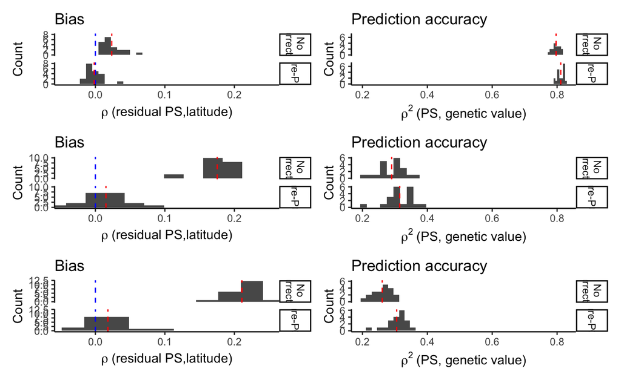

```r
plt.susie.bias = ggplot(prs.susie.summary)+
  geom_histogram(aes(rlat),bins=10)+
  facet_grid(correction~., labeller = as_labeller(
               c(pcs0 = "No \n correction",
                 re = "Rare-PCA")
               ))+
  theme_classic()+
  labs(x = bquote(rho~"(residual PS,latitude)"),
       y = "Count",
       title = "Bias")+
  geom_vline(xintercept = 0, color="blue", linetype = "dashed")+
  geom_vline(data = prs.susie.summary.mean,
             aes(xintercept = mean.rlat),
             linetype = "dashed",
             color = "red")+
  coord_cartesian(xlim = xrange.rlat)
plt.susie.r2 = ggplot(prs.susie.summary)+
  geom_histogram(aes(r2),bins=10)+
  facet_grid(correction~.,
             labeller = as_labeller(
               c(pcs0 = "No \n correction",
                 re = "Rare-PCA")
               ))+
  theme_classic()+
  labs(x = bquote(rho^2~"(PS, genetic value)"),
       y = "Count",
       title = "Prediction accuracy")+
  geom_vline(data = prs.susie.summary.mean,
             aes(xintercept = mean.r2),
             color = "red",
             linetype = "dashed")+
  coord_cartesian(xlim = xrange.r2)
plt.susie = plt.susie.bias + plt.susie.r2
plt.lead.bias = ggplot(mprs.lead.summary)+
  geom_histogram(aes(rlat),bins=10)+
  facet_grid(correction~., labeller = as_labeller(
               c(pcs0 = "No \n correction",
                 re = "Rare-PCA")
               ))+
  theme_classic()+
  labs(x = bquote(rho~"(residual PS,latitude)"),
       y = "Count",
       title = "Bias")+
  coord_cartesian(xlim = xrange.rlat)+
  geom_vline(xintercept = 0, color="blue", linetype = "dashed")+
  geom_vline(data = mprs.summary.lead.mean,
             aes(xintercept = mean.rlat),
             linetype = "dashed",
             color = "red")
plt.lead.r2 = ggplot(mprs.lead.summary)+
  geom_histogram(aes(r2),bins=10)+
  facet_grid(correction ~.,
             labeller = as_labeller(
               c(pcs0 = "No \n correction",
                 re = "Rare-PCA")
               ))+
  theme_classic()+
  labs(x = bquote(rho^2~"(PS, genetic value)"),
       y = "Count",
       title = "Prediction accuracy")+
  coord_cartesian(xlim = xrange.r2)+
  geom_vline(data = mprs.summary.lead.mean,
             aes(xintercept = mean.r2),
             linetype = "dashed",
             color = "red")
plt.lead = plt.lead.bias + plt.lead.r2
plt.causal.p.bias = ggplot(mprs.causal.p.summary)+
  geom_histogram(aes(rlat),bins=10)+
  facet_grid(correction~., labeller = as_labeller(
               c(pcs0 = "No \n correction",
                 re = "Rare-PCA")
               ))+
  theme_classic()+
  labs(x = bquote(rho~"(residual PS,latitude)"),
       y = "Count",
       title = "Bias")+
  coord_cartesian(xlim = xrange.rlat)+
  geom_vline(xintercept = 0, color="blue", linetype = "dashed")+
  geom_vline(data = mprs.summary.causal.p.mean,
             aes(xintercept = mean.rlat),
             linetype = "dashed",
             color = "red")
plt.causal.p.r2 = ggplot(mprs.causal.p.summary)+
  geom_histogram(aes(r2),bins=10)+
  facet_grid(correction ~.,
             labeller = as_labeller(
               c(pcs0 = "No \n correction",
                 re = "Rare-PCA")
               ))+
  theme_classic()+
  labs(x = bquote(rho^2~"(PS, genetic value)"),
       y = "Count",
       title = "Prediction accuracy")+
  coord_cartesian(xlim = xrange.r2)+
  geom_vline(data = mprs.summary.causal.p.mean,
             aes(xintercept = mean.r2),
             linetype = "dashed",
             color = "red")
plt.causal.p = plt.causal.p.bias + plt.causal.p.r2
plt.all = plt.causal.p / plt.lead / plt.susie
plt.all
```

```r
ggsave(F("plots/finemapping/finemapped_prs.pdf"),
       plt.all,
       height = 7,
       width = 7)
```